# *Churn Modelling Classification*

*Importing the required libraries & packages*

```python
import numpy as np
import pandas as pd
import os
import matplotlib.pyplot as plt
import seaborn as sns
from sklearn.preprocessing import StandardScaler
from sklearn.model_selection import train_test_split
from sklearn.ensemble import RandomForestClassifier
from sklearn.svm import SVC
from sklearn.ensemble import ExtraTreesClassifier
from xgboost import XGBClassifier
from catboost import CatBoostClassifier
from lightgbm import LGBMClassifier
from sklearn.model_selection import GridSearchCV,cross_val_score
import pickle
import ydata_profiling as pf
from sklearn.metrics import accuracy_score,classification_report,confusion_matrix
plt.rcParams['figure.figsize']=(20,14)
%matplotlib inline
import warnings
warnings.filterwarnings('ignore')
```

*Changing The Default Working Directory Path & Reading the Dataset using Pandas Command*

```python
os.chdir('D:\\bala\\study things\\data science\\Batch 74 Day 20\\Batch 74 Day 20\\')
df = pd.read_csv('Churn_Modelling.csv')
df.head()
```

|  | RowNumber | CustomerId | Surname | CreditScore | Geography | Gender | Age | Tenure | Balance | NumOfProducts | HasCrCard | IsActiveMember | EstimatedSalary | Exited |
| --- | --- | --- | --- | --- | --- | --- | --- | --- | --- | --- | --- | --- | --- | --- |
| 0 | 1 | 15634602 | Hargrave | 619 | France | Female | 42 | 2 | 0.00 | 1 | 1 | 1 | 101348.88 | 1 |
| 1 | 2 | 15647311 | Hill | 608 | Spain | Female | 41 | 1 | 83807.86 | 1 | 0 | 1 | 112542.58 | 0 |
| 2 | 3 | 15619304 | Onio | 502 | France | Female | 42 | 8 | 159660.80 | 3 | 1 | 0 | 113931.57 | 1 |
| 3 | 4 | 15701354 | Boni | 699 | France | Female | 39 | 1 | 0.00 | 2 | 0 | 0 | 93826.63 | 0 |
| 4 | 5 | 15737888 | Mitchell | 850 | Spain | Female | 43 | 2 | 125510.82 | 1 | 1 | 1 | 79084.10 | 0 |

## *Data Cleaning:*

*Dropping the column which is not needed for model fitting*

```python
df.drop(['RowNumber','CustomerId','Surname'],axis=1,inplace=True)
```

**_Automated Exploratory Data Analysis (EDA) with ydata_profiling(pandas*profiling)***

```python
pf.ProfileReport(df)
```

[interactive chart not shown]

*Label Encoding the Gender column*

```python
df['Gender']=df['Gender'].astype('category')
df['Gender']=df['Gender'].cat.codes
```

*One Hot Encoding the Geography column using pandas get dummies command*

```python
geo = pd.get_dummies(df['Geography'],drop_first=True)
df = pd.concat([geo,df],axis=1)
```

*Dropping out the Geography column after one hot encoding*

```python
df.drop(['Geography'],axis=1,inplace=True)
```

*Assigning the dependent and independent variable*

```python
x = df.iloc[:,:-1]
y = df.iloc[:,-1]
```

## *Data Preprocessing:*

*Standardizing the independent variable of the dataset*

```python
sc = StandardScaler()
x = sc.fit_transform(x)
```

## *Model Fitting:*

**_Defining the Function for the ML algorithms using GridSearchCV Algorithm and splitting the dependent variable & independent variable into training and test dataset and Predicting the Dependent Variable by fitting the given model and create the pickle file of the model with the given Algo*name. Further getting the Algorithm Name, Best Parameters of the algorithm, Accuracy Score in percentage format, Classification Report and Confusion Matrix between the predicted values and dependent test dataset.***

```python
def FitModel(x,y,algo_name,algorithm,gridSearchParams,cv):
    np.random.seed(10)
    x_train,x_test,y_train,y_test = train_test_split(x,y,test_size=0.3,random_state=100)
    grid = GridSearchCV(estimator=algorithm,param_grid=gridSearchParams,scoring='accuracy',
                        cv=cv,verbose=0,n_jobs=-1)
    grid_result = grid.fit(x_train,y_train)
    best_params = grid_result.best_params_
    y_pred = grid_result.predict(x_test)
    cm = confusion_matrix(y_test,y_pred)
    pickle.dump(grid_result,open(algo_name,'wb'))
    print('Algorithm Name:',algo_name,'\n')
    print('Best Params:',best_params,'\n')
    print('Accuracy {}%'.format(100*accuracy_score(y_test,y_pred)))
    print('\n classification Report:',classification_report(y_test,y_pred))
    print('\n confusion matrix:',cm)
```

*Running the function with some appropriate parameters and fitting the Support Vector Machine Classifiers Algorithm and getting the Algorithm Name, Best Parameters of the algorithm, Accuracy Score in percentage format, Classification Report and Confusion Matrix between the predicted values and dependent test dataset and also the pickle file with the name SVC.*

```python
params = {'C':[0.1,1,10,100,1000],
         'gamma':[0.0001,0.001,0.1,1,3,5,10,100]}
FitModel(x,y,'SVC',SVC(),params,cv=10)
```

```
Algorithm Name: SVC

Best Params: {'C': 1000, 'gamma': 0.001}

Accuracy 85.43333333333332%

 classification Report:               precision    recall  f1-score   support

           0       0.85      0.99      0.91      2376
           1       0.87      0.35      0.50       624

    accuracy                           0.85      3000
   macro avg       0.86      0.67      0.71      3000
weighted avg       0.86      0.85      0.83      3000


 confusion matrix: [[2343   33]
 [ 404  220]]
```

*Running the function with some appropriate parameters and fitting the Random Forest Classifiers Algorithm and getting the Algorithm Name, Best Parameters of the algorithm, Accuracy Score in percentage format, Classification Report and Confusion Matrix between the predicted values and dependent test dataset and also the pickle file with the name Random Forest.*

```python
params = {'n_estimators':[500,600,800,1000],
         'criterion':['gini','entropy']}
FitModel(x,y,'Random Forest',RandomForestClassifier(),params,cv=7)
```

```
Algorithm Name: Random Forest

Best Params: {'criterion': 'entropy', 'n_estimators': 500}

Accuracy 86.3%

 classification Report:               precision    recall  f1-score   support

           0       0.87      0.97      0.92      2376
           1       0.80      0.46      0.58       624

    accuracy                           0.86      3000
   macro avg       0.84      0.71      0.75      3000
weighted avg       0.86      0.86      0.85      3000


 confusion matrix: [[2304   72]
 [ 339  285]]
```

*Running the function with some appropriate parameters and fitting the XGBoost Classifiers Algorithm and getting the Algorithm Name, Best Parameters of the algorithm, Accuracy Score in percentage format, Classification Report and Confusion Matrix between the predicted values and dependent test dataset and also the pickle file with the name XGBoost.*

```python
params = {'n_estimators':[555,666,777,888,999]}
FitModel(x,y,'XGBoost',XGBClassifier(),params,cv=5)
```

```
Algorithm Name: XGBoost

Best Params: {'n_estimators': 555}

Accuracy 84.6%

 classification Report:               precision    recall  f1-score   support

           0       0.87      0.94      0.91      2376
           1       0.69      0.47      0.56       624

    accuracy                           0.85      3000
   macro avg       0.78      0.71      0.73      3000
weighted avg       0.83      0.85      0.83      3000


 confusion matrix: [[2243  133]
 [ 329  295]]
```

*Running the function with some appropriate parameters and fitting the Extra Tree Classifiers Algorithm and getting the Algorithm Name, Best Parameters of the algorithm, Accuracy Score in percentage format, Classification Report and Confusion Matrix between the predicted values and dependent test dataset and also the pickle file with the name ET.*

```python
params = {'n_estimators':[500,600,800,1000],
         'criterion':['gini','entropy'],
         'max_features':['auto','sqrt']}
FitModel(x,y,'ET',ExtraTreesClassifier(),params,cv=4)
```

```
Algorithm Name: ET

Best Params: {'criterion': 'gini', 'max_features': 'auto', 'n_estimators': 500}

Accuracy 86.43333333333332%

 classification Report:               precision    recall  f1-score   support

           0       0.87      0.97      0.92      2376
           1       0.81      0.45      0.58       624

    accuracy                           0.86      3000
   macro avg       0.84      0.71      0.75      3000
weighted avg       0.86      0.86      0.85      3000


 confusion matrix: [[2312   64]
 [ 343  281]]
```

*Running the function with empty parameters since the catboost model doesn't need any special parameters and fitting the CatBoost Classifiers Algorithm and getting the Algorithm Name, Empty Parameters of the algorithm, Accuracy Score in percentage format, Classification Report and Confusion Matrix between the predicted values and dependent test dataset and also the pickle file with the name CatBoost.*

```python
params = {}
FitModel(x,y,'CatBoost',CatBoostClassifier(),params,cv=10)
```

[output not shown]

[output cut: 964 more lines]

```

Accuracy 86.06666666666666%

 classification Report:               precision    recall  f1-score   support

           0       0.87      0.97      0.92      2376
           1       0.78      0.46      0.58       624

    accuracy                           0.86      3000
   macro avg       0.83      0.71      0.75      3000
weighted avg       0.85      0.86      0.85      3000


 confusion matrix: [[2294   82]
 [ 336  288]]
```

*Running the function with empty parameters since the lightgbm model doesn't need any special parameters and fitting the LGBM Classifiers Algorithm and getting the Algorithm Name, Empty Parameters of the algorithm, Accuracy Score in percentage format, Classification Report and Confusion Matrix between the predicted values and dependent test dataset and also the pickle file with the name LightGBM.*

```python
params = {}
FitModel(x,y,'lightGBM',LGBMClassifier(),params,cv=10)
```

```
Algorithm Name: lightGBM

Best Params: {}

Accuracy 86.2%

 classification Report:               precision    recall  f1-score   support

           0       0.88      0.96      0.92      2376
           1       0.76      0.49      0.60       624

    accuracy                           0.86      3000
   macro avg       0.82      0.72      0.76      3000
weighted avg       0.85      0.86      0.85      3000


 confusion matrix: [[2281   95]
 [ 319  305]]
```

*Loading the pickle file with the algorithm which gives highest accuracy percentage*

```python
model = pickle.load(open('ET','rb'))
```

*Predicting the dependent variable using the loaded pickle file and getting the Accuracy Score in percentage format, Classification Report and Confusion Matrix between the predicted values and dependent variable*

```python
y_pred = model.predict(x)
print('Accuracy Score {}%'.format(100*accuracy_score(y,y_pred)))
print('\n Classification Report:',classification_report(y,y_pred))
print('\n Confusion Matrix:',confusion_matrix(y,y_pred))
```

```
Accuracy Score 95.93%

 Classification Report:               precision    recall  f1-score   support

           0       0.96      0.99      0.97      7963
           1       0.96      0.83      0.89      2037

    accuracy                           0.96     10000
   macro avg       0.96      0.91      0.93     10000
weighted avg       0.96      0.96      0.96     10000


 Confusion Matrix: [[7899   64]
 [ 343 1694]]
```

*Making the Predicted value as a new dataframe and concating it with the given data*

```python
prediction=pd.DataFrame(y_pred,columns=['Prediction of Exited(Approx.)'])
pred_df=pd.concat([df,prediction],axis=1)
```

*Exporting the Data With Prediction of Exited to a csv file*

```python
pred_df.to_csv('Predicted Churn Modelling.csv',index=False)
```

*Plotting the line graph to represent the Accuracy between Predicted value and Actual Value and saving the PNG file*

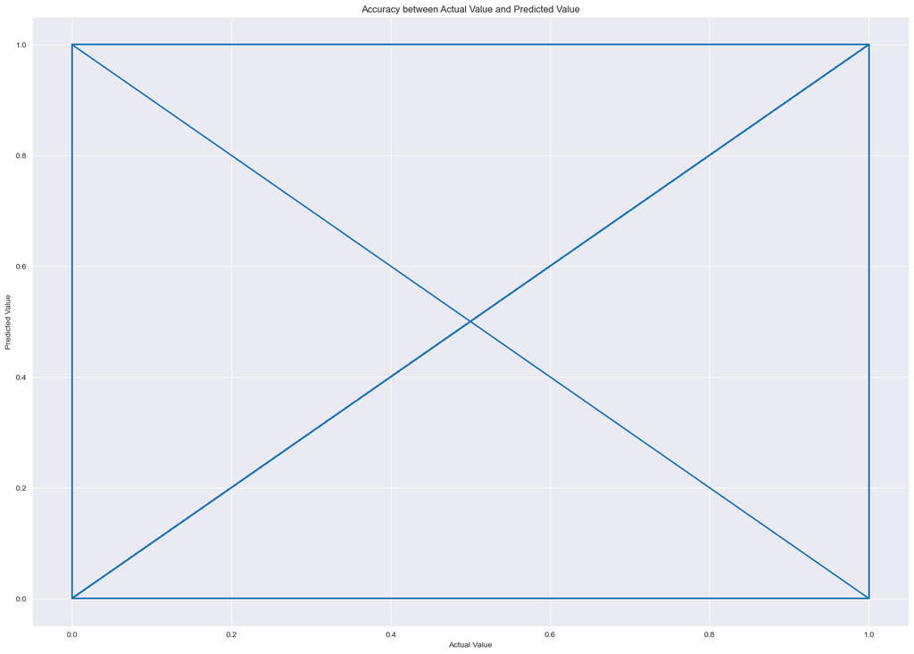

```python
sns.set_style('darkgrid')
plt.plot(y,y_pred)
plt.xlabel('Actual Value')
plt.ylabel('Predicted Value')
plt.title('Accuracy between Actual Value and Predicted Value')
plt.savefig('Accuracy between Actual Value and Predicted Value.png')
plt.show()
```